# 3. Facial Keypoint Detection, Complete Pipeline

## Face and Facial Keypoint detection

After you've trained a neural network to detect facial keypoints, you can then apply this network to *any* image that includes faces. The neural network expects a Tensor of a certain size as input and, so, to detect any face, you'll first have to do some pre-processing.

1. Detect all the faces in an image using a face detector (we'll be using a Haar Cascade detector in this notebook).
2. Pre-process those face images so that they are grayscale, and transformed to a Tensor of the input size that your net expects. This step will be similar to the `data_transform` you created and applied in Notebook 2, whose job was tp rescale, normalize, and turn any image into a Tensor to be accepted as input to your CNN.
3. Use your trained model to detect facial keypoints on the image.

In the next python cell we load in required libraries for this section of the project.

```python
import numpy as np
import matplotlib.pyplot as plt
import matplotlib.image as mpimg
%matplotlib inline
```

#### Select an image

Select an image to perform facial keypoint detection on; you can select any image of faces in the `images/` directory.

[figure not shown]

```python
import cv2
# load in color image for face detection
image = cv2.imread('images/obamas.jpg')

# switch red and blue color channels
# --> by default OpenCV assumes BLUE comes first, not RED as in many images
image = cv2.cvtColor(image, cv2.COLOR_BGR2RGB)

# plot the image
fig = plt.figure(figsize=(9,9))
plt.imshow(image)
```

## Detect all faces in an image

Next, you'll use one of OpenCV's pre-trained Haar Cascade classifiers, all of which can be found in the `detector_architectures/` directory, to find any faces in your selected image.

In the code below, we loop over each face in the original image and draw a red square on each face (in a copy of the original image, so as not to modify the original). You can even [add eye detections](https://docs.opencv.org/3.4.1/d7/d8b/tutorial_py_face_detection.html) as an *optional* exercise in using Haar detectors.

An example of face detection on a variety of images is shown below.

[figure not shown]

[figure not shown]

```python
# load in a haar cascade classifier for detecting frontal faces
face_cascade = cv2.CascadeClassifier('detector_architectures/haarcascade_frontalface_default.xml')

# run the detector
# the output here is an array of detections; the corners of each detection box
# if necessary, modify these parameters until you successfully identify every face in a given image
faces = face_cascade.detectMultiScale(image, 3., 6)

# make a copy of the original image to plot detections on
image_with_detections = image.copy()

# loop over the detected faces, mark the image where each face is found
for (x,y,w,h) in faces:
    # draw a rectangle around each detected face
    # you may also need to change the width of the rectangle drawn depending on image resolution
    cv2.rectangle(image_with_detections,(x,y),(x+w,y+h),(255,0,0),3)

fig = plt.figure(figsize=(9,9))

plt.imshow(image_with_detections)
```

## Loading in a trained model

Once you have an image to work with (and, again, you can select any image of faces in the `images/` directory), the next step is to pre-process that image and feed it into your CNN facial keypoint detector.

First, load your best model by its filename.

```python
import torch
from models import Net

net = Net()

## TODO: load the best saved model parameters (by your path name)
## You'll need to un-comment the line below and add the correct name for *your* saved model
net.load_state_dict(torch.load('saved_models/keypoints_model_1.pt'))
#net.load_state_dict(torch.load('saved_models/model_best.pth'))
```

```
<All keys matched successfully>
```

## Keypoint detection

Now, we'll loop over each detected face in an image (again!) only this time, you'll transform those faces in Tensors that your CNN can accept as input images.

### TODO: Transform each detected face into an input Tensor

You'll need to perform the following steps for each detected face:

1. Convert the face from RGB to grayscale
2. Normalize the grayscale image so that its color range falls in [0,1] instead of [0,255]
3. Rescale the detected face to be the expected square size for your CNN (224x224, suggested)
4. Reshape the numpy image into a torch image.

You may find it useful to consult to transformation code in `data_load.py` to help you perform these processing steps.

### TODO: Detect and display the predicted keypoints

After each face has been appropriately converted into an input Tensor for your network to see as input, you'll wrap that Tensor in a Variable() and can apply your `net` to each face. The ouput should be the predicted the facial keypoints. These keypoints will need to be "un-normalized" for display, and you may find it helpful to write a helper function like `show_keypoints`. You should end up with an image like the following with facial keypoints that closely match the facial features on each individual face:

[figure not shown]

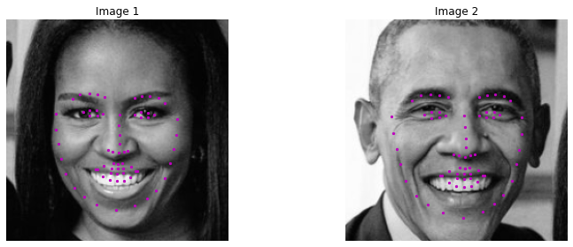

```python
device = torch.device("cuda" if torch.cuda.is_available() else "cpu")
net = net.to(device).eval()

plt.figure(figsize=(12, 4))
kps = []

for i, (x, y, w, h) in enumerate(faces):
    # --- Crop and preprocess ROI ---
    roi = image[y:y+h, x:x+w]
    roi = cv2.cvtColor(roi, cv2.COLOR_RGB2GRAY)
    roi = cv2.resize(roi, (224, 224), interpolation=cv2.INTER_LINEAR)
    roi = roi.astype(np.float32) / 255.0
    roi_tensor = torch.from_numpy(roi).unsqueeze(0).unsqueeze(0).to(device)

    # --- Predict keypoints ---
    with torch.no_grad():
        output = net(roi_tensor).view(-1, 68, 2).cpu().numpy()[0]
    output = output * 50.0 + 100  # denormalize
    kps.append(output)

    # --- Display results ---
    plt.subplot(1, len(faces), i + 1)
    plt.imshow(roi, cmap='gray')
    plt.scatter(output[:, 0], output[:, 1], s=20, c='m', marker='.')
    plt.title(f"Image {i + 1}")
    plt.axis('off')

plt.tight_layout()
plt.show()
```

## Face Swapping Implementation (with Facial Keypoints)

This section implements a complete face-swapping pipeline using facial keypoints detected by a convolutional neural network.

The goal is to take two detected faces within the same image, using the prediction of their 68 key facial landmarks, and then swap the facial regions between them while preserving shape, alignment, and natural appearance.

### Concept Overview

1. **Keypoint Prediction** (check previous cells)  
   Each detected face is cropped, resized (to 224×224), and passed through a trained CNN that predicts 68 facial keypoints.
2. **Mapping Keypoints to the Original Image**  
   The predicted keypoints are scaled back from the cropped coordinates to the global pixel coordinates of the original image.
3. **Face Warping (Triangular Mesh Transformation)**  
   A Delaunay triangulation is computed using the keypoints of both faces.  
   Each triangle from face A is warped to its corresponding triangle in face B using affine transformations, creating a geometrically consistent deformation.
4. **Seamless Blending**  
   The warped face is then merged with the target face using OpenCV’s `seamlessClone()` function, which performs Poisson blending.
5. **Mask Definition**  
   Only the keypoints 1–27 (covering the jawline and eyebrows) are used to define the facial region mask for blending, preventing background overlap.

> **Acknowledgement**  
> Some sections of this implementation were refined with the help of an AI assistant, mainly for code structuring, clarity, and optimisation.  
> All design logic, debugging, and testing were performed by the author.

```python
# 1) kps (224) -> global pixel coords
import numpy as np
import cv2

def kps_from_crops_to_global(faces, kps_list, input_size=224):
    """
    faces: [(x, y, w, h), ...]
    kps_list: [(68, 2) in 224×224 crop coords, ...]
    returns: [(68, 2) in global pixel coords, ...]
    """
    global_kps = []
    for (x, y, w, h), pts in zip(faces, kps_list):
        scale = np.array([w / input_size, h / input_size], dtype=np.float32)
        pts_g = pts.astype(np.float32) * scale + np.array([x, y], dtype=np.float32)
        global_kps.append(pts_g)
    return global_kps
```

```python
# 2) warping utilities

def apply_affine_transform(src, src_tri, dst_tri, size):
    M = cv2.getAffineTransform(np.float32(src_tri), np.float32(dst_tri))
    return cv2.warpAffine(
        src, M, (size[0], size[1]),
        flags=cv2.INTER_LINEAR, borderMode=cv2.BORDER_REFLECT_101
    )

def warp_triangle(src, dst, t_src, t_dst):
    r1 = cv2.boundingRect(np.float32([t_src]))
    r2 = cv2.boundingRect(np.float32([t_dst]))

    t1_rect = [(t_src[i][0] - r1[0], t_src[i][1] - r1[1]) for i in range(3)]
    t2_rect = [(t_dst[i][0] - r2[0], t_dst[i][1] - r2[1]) for i in range(3)]

    mask = np.zeros((r2[3], r2[2], 3), dtype=np.float32)
    cv2.fillConvexPoly(mask, np.int32([t2_rect]), (1.0, 1.0, 1.0), lineType=cv2.LINE_AA)

    src_rect = src[r1[1]:r1[1] + r1[3], r1[0]:r1[0] + r1[2]]
    warped = apply_affine_transform(src_rect, t1_rect, t2_rect, (r2[2], r2[3]))

    dst_slice = dst[r2[1]:r2[1] + r2[3], r2[0]:r2[0] + r2[2]]
    dst_slice *= (1 - mask)
    dst_slice += warped * mask
    dst[r2[1]:r2[1] + r2[3], r2[0]:r2[0] + r2[2]] = dst_slice

def delaunay_tris(rect, pts):
    subdiv = cv2.Subdiv2D(rect)
    for p in pts:
        subdiv.insert((float(p[0]), float(p[1])))
    tlist = subdiv.getTriangleList()

    def find_idx(pt):
        d = np.sum((pts - pt) ** 2, axis=1)
        k = int(np.argmin(d))
        return k if d[k] < 4.0 else -1  # 2 px tolerance

    tris = []
    x, y, w, h = rect
    for t in tlist:
        tri = np.array([(t[0], t[1]), (t[2], t[3]), (t[4], t[5])], dtype=np.float32)
        inside = np.all((x <= tri[:, 0]) & (tri[:, 0] < x + w) &
                        (y <= tri[:, 1]) & (tri[:, 1] < y + h))
        if inside:
            idx = [find_idx(tri[i]) for i in range(3)]
            if min(idx) >= 0 and len(set(idx)) == 3:
                tris.append(tuple(idx))
    return tris

def mask_from_subset(shape, pts, idx_subset):
    hull = cv2.convexHull(pts[idx_subset].astype(np.int32))
    mask = np.zeros(shape, dtype=np.uint8)
    cv2.fillConvexPoly(mask, hull, (255, 255, 255))
    x, y, w, h = cv2.boundingRect(hull)
    centre = (x + w // 2, y + h // 2)
    return mask, centre
```

```python
# 3) main swap function — uses: image (RGB), faces, kps_list (in 224 coords)

def swap_two_faces_from_crops(
    image_rgb, faces, kps_list, input_size=224,
    mask_idx=None, clone_mode=cv2.NORMAL_CLONE
):
    """
    image_rgb: uint8 RGB (H, W, 3)
    faces: [(x,y,w,h), (x,y,w,h)]
    kps_list: [(68,2) in 224×224 crop coords, (68,2) in 224×224 crop coords]
    mask_idx: landmark indices to build the mask (default 0..26 → points 1–27)
    """
    if len(faces) != 2 or len(kps_list) != 2:
        raise ValueError("This function assumes exactly two faces.")

    if mask_idx is None:
        mask_idx = np.arange(0, 27, dtype=np.int32)  # points 1–27

    # global keypoints
    ptsA, ptsB = kps_from_crops_to_global(faces, kps_list, input_size=input_size)
    ptsA = ptsA.astype(np.float32)
    ptsB = ptsB.astype(np.float32)

    # to BGR float
    img_bgr = cv2.cvtColor(image_rgb, cv2.COLOR_RGB2BGR)
    img = img_bgr.astype(np.float32) / 255.0
    H, W = img.shape[:2]
    rect = (0, 0, W, H)

    # single triangulation on the midpoint set (stable)
    mid = ((ptsA + ptsB) * 0.5).astype(np.float32)
    tris = delaunay_tris(rect, mid)

    # A -> B
    canvas = img.copy()
    for (i, j, k) in tris:
        warp_triangle(img, canvas, [ptsA[i], ptsA[j], ptsA[k]],
                                   [ptsB[i], ptsB[j], ptsB[k]])
    maskB, centreB = mask_from_subset((H, W, 3), ptsB, mask_idx)
    blended1 = cv2.seamlessClone(
        (canvas * 255).astype(np.uint8),
        (img * 255).astype(np.uint8),
        maskB, centreB, clone_mode
    ).astype(np.float32) / 255.0

    # B -> A
    canvas2 = blended1.copy()
    for (i, j, k) in tris:
        warp_triangle(img, canvas2, [ptsB[i], ptsB[j], ptsB[k]],
                                   [ptsA[i], ptsA[j], ptsA[k]])
    maskA, centreA = mask_from_subset((H, W, 3), ptsA, mask_idx)
    blended2 = cv2.seamlessClone(
        (canvas2 * 255).astype(np.uint8),
        (blended1 * 255).astype(np.uint8),
        maskA, centreA, clone_mode
    )

    return cv2.cvtColor(blended2, cv2.COLOR_BGR2RGB)
```

[figure not shown]

[figure not shown]

```python
# 4) example usage

# image: RGB uint8 (H, W, 3)
# faces: [(x, y, w, h), (x, y, w, h)]
# kps:   [np.ndarray (68,2) in 224×224 crop coords, np.ndarray (68,2)]

out_img = swap_two_faces_from_crops(
    image, faces, kps, input_size=224,
    mask_idx=np.arange(0, 27)  # landmarks 1–27
)

plt.figure(figsize=(10,8)); plt.imshow(image); plt.axis('off'); plt.show()
plt.figure(figsize=(10,8)); plt.imshow(out_img); plt.axis('off'); plt.show()
```